# Data Science - Practical Machine Learning Assignment

Jia Lin

May 18, 2016

## Executive Summary

This write-up is the assignment work for Practical Machine Learning on coursera. In this assignment we will use the human activity recognition data and predict the manner of exercise.

## Source of Data

The data of this assignment comes from [Human Activity Recognition project](http://groupware.les.inf.puc-rio.br/har). This research is using devices such as Jawbone Up, Nike FuelBand, and Fitbit it is now possible to collect a large amount of data about personal activity relatively inexpensively. These type of devices are part of the quantified self movement - a group of enthusiasts who take measurements about themselves regularly to improve their health, to find patterns in their behavior, or because they are tech geeks.  
Training Data:[https://d396qusza40orc.cloudfront.net/predmachlearn/pml-training.csv](https://d396qusza40orc.cloudfront.net/predmachlearn/pml-training.csv)  
Testing Data: https://d396qusza40orc.cloudfront.net/predmachlearn/pml-testing.csv

```r
download.file("https://d396qusza40orc.cloudfront.net/predmachlearn/pml-training.csv", "training.csv" )
download.file("https://d396qusza40orc.cloudfront.net/predmachlearn/pml-testing.csv", "testing.csv")
df<- read.csv("training.csv", na.strings = c("NA", ""))
quiz <- read.csv("testing.csv", na.strings = c("NA", ""))
```

## Data Cleaning

First all of all, we will remove the first 6 columns which are information only, not part of the collected data.  
We also notice there are quite large amount data are NA data. We shall make sense of the distribution of the NA data in all columns first.

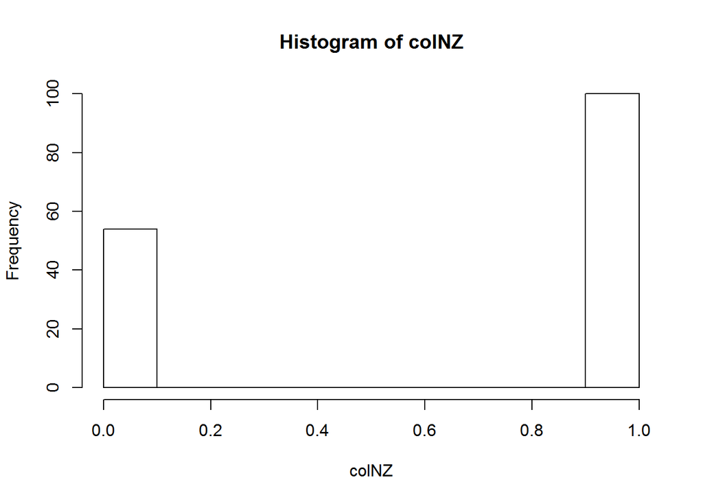

```r
df <- df[, -c(1:6)]
colNZ <- sapply(df, function(x) {sum(is.na(x))/length(x)})
hist(colNZ)
```

As the histogram shows, we will choose 0.9 as the factor. This means our model will not include those columns with more than 90% NA values.

```r
df <- subset(df[, which(colNZ<0.9)])
set.seed(2016)
inTrain <- createDataPartition(df$classe, p=3/4 )[[1]]
training <- df[inTrain, ]
testing <- df[-inTrain,]
```

After data cleaning up, dimension of the the training and testing data:

```r
dim(training)
```

```
## [1] 14718    54
```

```r
dim(testing)
```

```
## [1] 4904   54
```

## Variable correlation matrix

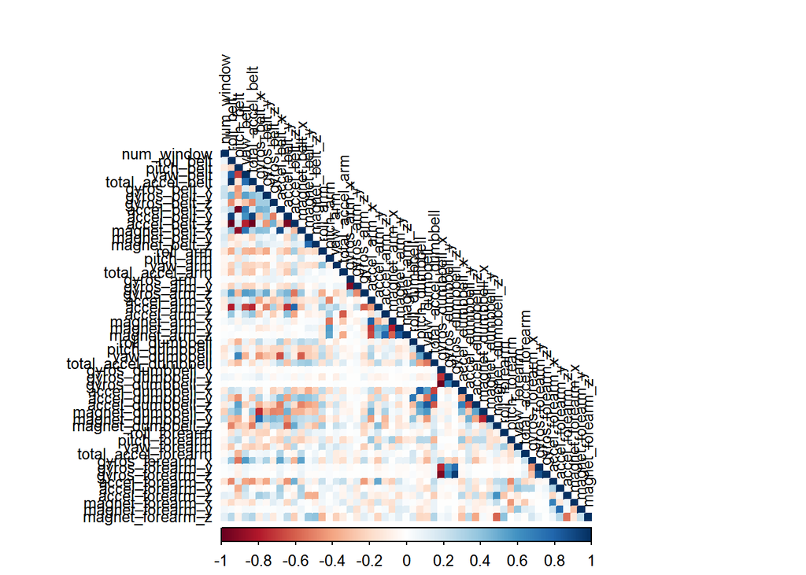

```r
corrMatrix <- cor(training[, - 54])
corrplot(corrMatrix, method="color", type="lower", tl.cex = 0.8, tl.col = rgb(0, 0, 0))
```

## Random Forest Model

We will apply random forest model and calculate the accuracy here.

```r
fitRF <- train(classe ~., method=“rf”, data=training, prox=FALSE)
```

Use testing set to validate the accuracy.

```r
preRF <- predict(fitRF, testing)
confusionMatrix(preRF, testing$classe)
```

```
## Confusion Matrix and Statistics
##
##           Reference
## Prediction    A    B    C    D    E
##          A 1395    2    0    0    0
##          B    0  946    1    0    0
##          C    0    1  854    1    0
##          D    0    0    0  803    0
##          E    0    0    0    0  901
##
## Overall Statistics
##
##                Accuracy : 0.999
##                  95% CI : (0.9976, 0.9997)
##     No Information Rate : 0.2845
##     P-Value [Acc > NIR] : < 2.2e-16
##
##                   Kappa : 0.9987
##  Mcnemar's Test P-Value : NA
##
## Statistics by Class:
##
##                      Class: A Class: B Class: C Class: D Class: E
## Sensitivity            1.0000   0.9968   0.9988   0.9988   1.0000
## Specificity            0.9994   0.9997   0.9995   1.0000   1.0000
## Pos Pred Value         0.9986   0.9989   0.9977   1.0000   1.0000
## Neg Pred Value         1.0000   0.9992   0.9998   0.9998   1.0000
## Prevalence             0.2845   0.1935   0.1743   0.1639   0.1837
## Detection Rate         0.2845   0.1929   0.1741   0.1637   0.1837
## Detection Prevalence   0.2849   0.1931   0.1746   0.1637   0.1837
## Balanced Accuracy      0.9997   0.9983   0.9992   0.9994   1.0000
```

As this model already has 99.9% accuracy, we will adopt this model and apply to the 20 quiz questions.

```r
quizRf <- predict(fitRF, quiz)
quizRf
```

```
##  [1] B A B A A E D B A A B C B A E E A B B B
## Levels: A B C D E
```